# Project1 MachineLearning Apr15

S.N

Saturday, April 25, 2015

## Purpose

To predict the manner in which 6 participants have exercised based on the given dataset generated from accelerometers on the belt, forearm, arm, and dumbell of the participants. There are five different possible manners, 1 is the correct manner while the other 4 are incorrect: A,B,C,D,E. This is ‘classe’ variable in the dataset which will be the outcome while the other variables in the dataset are predictors

## Method

1. Tidy the data set

A number of variables have empty observations and DIV/0. This is replaced by entering NA in lieu of these observations. There are some variables which have no observations at all. These will be removed for the training dataset.

```r
#Load data
training <- read.csv(file="pml-training.csv",header=TRUE)
testing <- read.csv(file="pml-testing.csv",header=TRUE)

#clean data remvove NA and DIV/0
training[training == ""] <- NA
training[training == "#DIV/0!"] <- NA
training <- training[,colSums(is.na(training)) == 0]
```

2. Exploratory plot

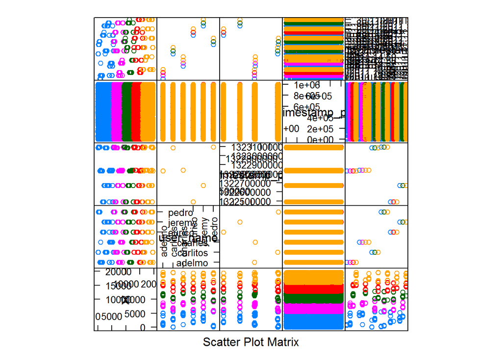

```r
library(caret)
set.seed(10000)

featurePlot(x=training[,(1:5)],y=training$classe,plot="pairs")
```

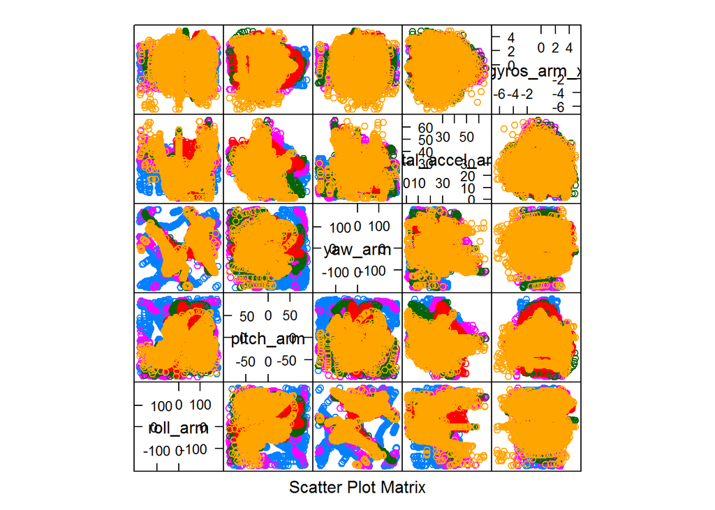

```r
featurePlot(x=training[,(21:25)],y=training$classe,plot="pairs")
```

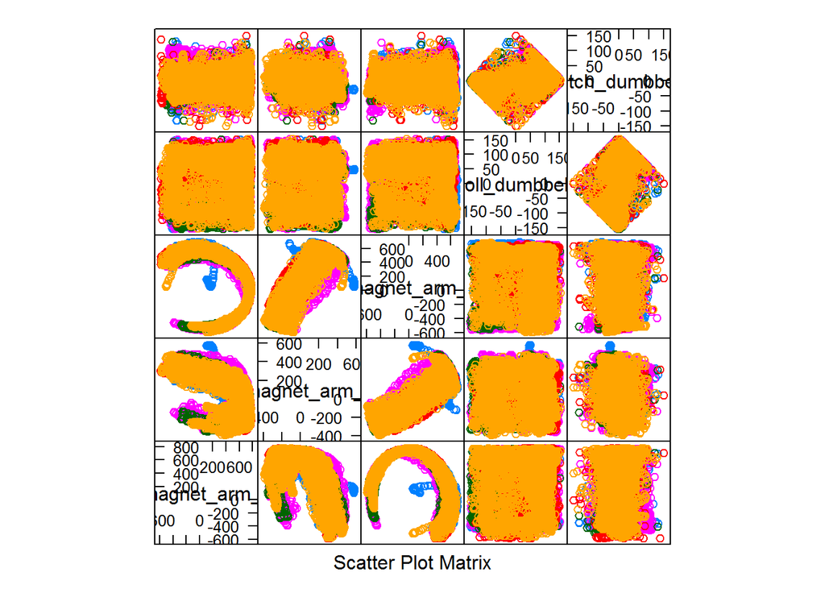

```r
featurePlot(x=training[,(31:35)],y=training$classe,plot="pairs")
```

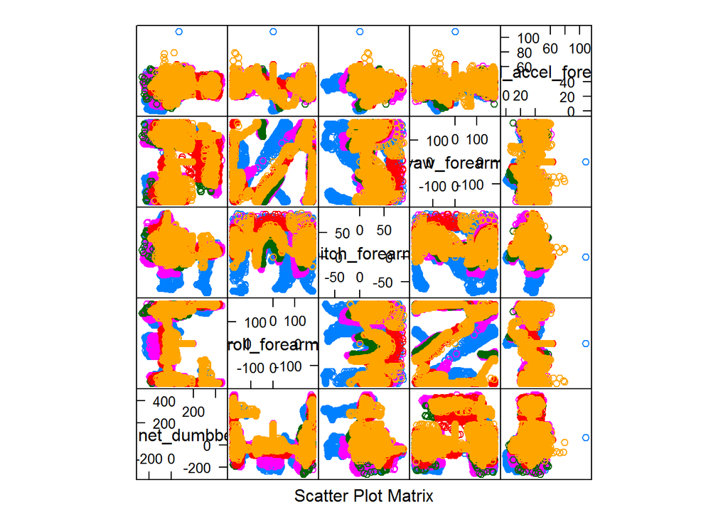

```r
featurePlot(x=training[,(46:50)],y=training$classe,plot="pairs")
```

In the dataset there are also predictors which may not have a strong effect on the outcome. Variables such as “X”, “user_name”, the various timestamps should be independent of the outcome and thus can be removed before being fed into the training algorithm.

In addition a zero covariate analysis is performed. Variables with nzv = TRUE can be removed from the training dataset. These predictors are near a near zero variance predictor, which means that the values are unique relative to the sample size such that it is essentially a constant and as a result does not have a bearing on the outcome.

```r
#Remove zero covariates
nearZeroVar(training,saveMetrics=TRUE)
```

```
##                      freqRatio percentUnique zeroVar   nzv
## X                     1.000000  100.00000000   FALSE FALSE
## user_name             1.100679    0.03057792   FALSE FALSE
## raw_timestamp_part_1  1.000000    4.26562022   FALSE FALSE
## raw_timestamp_part_2  1.000000   85.53154622   FALSE FALSE
## cvtd_timestamp        1.000668    0.10192641   FALSE FALSE
## new_window           47.330049    0.01019264   FALSE  TRUE
## num_window            1.000000    4.37264295   FALSE FALSE
## roll_belt             1.101904    6.77810621   FALSE FALSE
## pitch_belt            1.036082    9.37722964   FALSE FALSE
## yaw_belt              1.058480    9.97349913   FALSE FALSE
## total_accel_belt      1.063160    0.14779329   FALSE FALSE
## gyros_belt_x          1.058651    0.71348486   FALSE FALSE
## gyros_belt_y          1.144000    0.35164611   FALSE FALSE
## gyros_belt_z          1.066214    0.86127816   FALSE FALSE
## accel_belt_x          1.055412    0.83579655   FALSE FALSE
## accel_belt_y          1.113725    0.72877383   FALSE FALSE
## accel_belt_z          1.078767    1.52379982   FALSE FALSE
## magnet_belt_x         1.090141    1.66649679   FALSE FALSE
## magnet_belt_y         1.099688    1.51870350   FALSE FALSE
## magnet_belt_z         1.006369    2.32901845   FALSE FALSE
## roll_arm             52.338462   13.52563449   FALSE FALSE
## pitch_arm            87.256410   15.73234125   FALSE FALSE
## yaw_arm              33.029126   14.65701763   FALSE FALSE
## total_accel_arm       1.024526    0.33635715   FALSE FALSE
## gyros_arm_x           1.015504    3.27693405   FALSE FALSE
## gyros_arm_y           1.454369    1.91621649   FALSE FALSE
## gyros_arm_z           1.110687    1.26388747   FALSE FALSE
## accel_arm_x           1.017341    3.95984099   FALSE FALSE
## accel_arm_y           1.140187    2.73672409   FALSE FALSE
## accel_arm_z           1.128000    4.03628580   FALSE FALSE
## magnet_arm_x          1.000000    6.82397309   FALSE FALSE
## magnet_arm_y          1.056818    4.44399144   FALSE FALSE
## magnet_arm_z          1.036364    6.44684538   FALSE FALSE
## roll_dumbbell         1.022388   84.20650290   FALSE FALSE
## pitch_dumbbell        2.277372   81.74498012   FALSE FALSE
## yaw_dumbbell          1.132231   83.48282540   FALSE FALSE
## total_accel_dumbbell  1.072634    0.21914178   FALSE FALSE
## gyros_dumbbell_x      1.003268    1.22821323   FALSE FALSE
## gyros_dumbbell_y      1.264957    1.41677709   FALSE FALSE
## gyros_dumbbell_z      1.060100    1.04984201   FALSE FALSE
## accel_dumbbell_x      1.018018    2.16593619   FALSE FALSE
## accel_dumbbell_y      1.053061    2.37488533   FALSE FALSE
## accel_dumbbell_z      1.133333    2.08949139   FALSE FALSE
## magnet_dumbbell_x     1.098266    5.74864948   FALSE FALSE
## magnet_dumbbell_y     1.197740    4.30129447   FALSE FALSE
## magnet_dumbbell_z     1.020833    3.44511263   FALSE FALSE
## roll_forearm         11.589286   11.08959331   FALSE FALSE
## pitch_forearm        65.983051   14.85577413   FALSE FALSE
## yaw_forearm          15.322835   10.14677403   FALSE FALSE
## total_accel_forearm   1.128928    0.35674243   FALSE FALSE
## gyros_forearm_x       1.059273    1.51870350   FALSE FALSE
## gyros_forearm_y       1.036554    3.77637346   FALSE FALSE
## gyros_forearm_z       1.122917    1.56457038   FALSE FALSE
## accel_forearm_x       1.126437    4.04647844   FALSE FALSE
## accel_forearm_y       1.059406    5.11160942   FALSE FALSE
## accel_forearm_z       1.006250    2.95586586   FALSE FALSE
## magnet_forearm_x      1.012346    7.76679238   FALSE FALSE
## magnet_forearm_y      1.246914    9.54031189   FALSE FALSE
## magnet_forearm_z      1.000000    8.57710733   FALSE FALSE
## classe                1.469581    0.02548160   FALSE FALSE
```

```r
#new_window variable can be removed from above
```

Variable “new_window” can also be removed from the training set

```r
#remove "X", "username" and "timestamps" and "new_window"
training_subset <- training[,c(-1,-2,-3,-4,-5,-6)]
```

3. Partition dataset for training and validation

Two machine learning algorithms are selected to develop the prediction model: 1) Rpart Prediction Tree and 2) Random Forest.

```r
#split training set into smaller set
inTrain <- createDataPartition(y=training_subset$classe,p=0.05,list=FALSE)
trainingvalidate <- training_subset[-inTrain,]
trainingsplit <- training_subset[inTrain,]
```

## MODEL 1 - Using rpart Prediction Tree

Train the model using **rpart** and assign to object **FitmodelRpoart** with predictions assigned to **predictRpartValidate**:

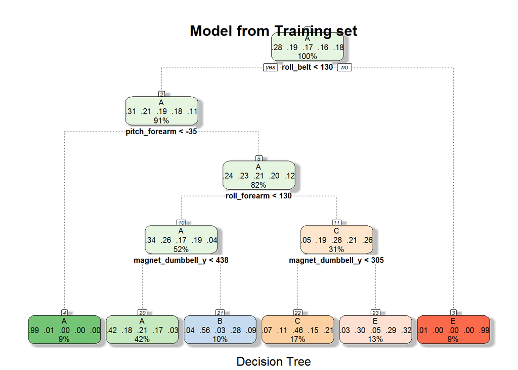

```r
FitModelRpart <- train(classe ~ .,data=trainingsplit,method="rpart")
predictRpartValidate <- predict(FitModelRpart,trainingvalidate)

library(rattle)
fancyRpartPlot(FitModelRpart$finalModel,main="Model from Training set",sub="Decision Tree")
```

The accuracy of the rpart model prediction against actual validation outcome is checked:

```r
#Check accuracy
confusionMatrix(trainingvalidate$classe,predictRpartValidate)
```

```
## Confusion Matrix and Statistics
##
##           Reference
## Prediction    A    B    C    D    E
##          A 4777   83  280    0  161
##          B 1575  914  345    0  773
##          C 1619   51 1416    0  164
##          D 1401  515  491    0  648
##          E  486  186  480    0 2274
##
## Overall Statistics
##
##                Accuracy : 0.5033
##                  95% CI : (0.4961, 0.5105)
##     No Information Rate : 0.5289
##     P-Value [Acc > NIR] : 1
##
##                   Kappa : 0.3495
##  Mcnemar's Test P-Value : <2e-16
##
## Statistics by Class:
##
##                      Class: A Class: B Class: C Class: D Class: E
## Sensitivity            0.4846  0.52258  0.47012       NA   0.5657
## Specificity            0.9403  0.84056  0.88264   0.8361   0.9212
## Pos Pred Value         0.9012  0.25340  0.43569       NA   0.6637
## Neg Pred Value         0.6191  0.94445  0.89629       NA   0.8852
## Prevalence             0.5289  0.09384  0.16160   0.0000   0.2157
## Detection Rate         0.2563  0.04904  0.07597   0.0000   0.1220
## Detection Prevalence   0.2844  0.19352  0.17437   0.1639   0.1838
## Balanced Accuracy      0.7125  0.68157  0.67638       NA   0.7434
```

The matrix indicates the model has missed the prediction for classe=“D” completely and the accuracy is 50%.

## MODEL 2 - Using Random Forest

A second model is created using **Random Forest** method with **FitModelForest** holding the model and **predictRForestvalidate** holding predictions:

```r
FitModelRForest <- train(classe ~ .,data=trainingsplit,method="rf",prox=TRUE,trControl=trainControl(preProcOptions=list(k=3)))
#Predict validation dataset with training model
predictRForestvalidate <- predict(FitModelRForest,trainingvalidate)
```

The accuracy of the random forest prediction model against actual validation outcome is checked:

```r
confusionMatrix(trainingvalidate$classe,predictRForestvalidate)
```

```
## Confusion Matrix and Statistics
##
##           Reference
## Prediction    A    B    C    D    E
##          A 5188   79   30    1    3
##          B  201 3202  157   31   16
##          C    1  119 3032   95    3
##          D   51   84  152 2763    5
##          E   16  106   41  128 3135
##
## Overall Statistics
##
##                Accuracy : 0.9292
##                  95% CI : (0.9255, 0.9329)
##     No Information Rate : 0.2928
##     P-Value [Acc > NIR] : < 2.2e-16
##
##                   Kappa : 0.9104
##  Mcnemar's Test P-Value : < 2.2e-16
##
## Statistics by Class:
##
##                      Class: A Class: B Class: C Class: D Class: E
## Sensitivity            0.9507   0.8919   0.8886   0.9155   0.9915
## Specificity            0.9914   0.9731   0.9857   0.9813   0.9812
## Pos Pred Value         0.9787   0.8877   0.9329   0.9044   0.9151
## Neg Pred Value         0.9798   0.9742   0.9753   0.9836   0.9982
## Prevalence             0.2928   0.1926   0.1831   0.1619   0.1696
## Detection Rate         0.2783   0.1718   0.1627   0.1482   0.1682
## Detection Prevalence   0.2844   0.1935   0.1744   0.1639   0.1838
## Balanced Accuracy      0.9711   0.9325   0.9372   0.9484   0.9863
```

Compared to rpart prediction tree, the accuracy of the random forest model is better, i.e. 92% vs 50%. The random forest model is able to predict a larger percentage of testcases correctly in the validation dataset, specifically, it has managed to predict the classe D outcomes compared to the misses in the rpart prediction tree model.

The random forest model shall be used for prediction. There are still mispredictions based on the comparison in confusionMatrix. The model performance can be improved further by eliminating more variables which are not substantial predictors to the outcome. The purpose of this is to reduce the chances of overfitting the model to the training set in order to improve robustness when applied against the test set. This is done by using varImp() to determine the top predictors.

```r
#find important variables
varImp(FitModelRForest)
```

```
## rf variable importance
##
##   only 20 most important variables shown (out of 53)
##
##                      Overall
## roll_belt             100.00
## num_window             82.02
## pitch_forearm          80.49
## roll_forearm           56.49
## magnet_dumbbell_y      48.24
## magnet_dumbbell_z      44.35
## pitch_belt             30.78
## accel_dumbbell_y       28.58
## yaw_belt               26.17
## roll_dumbbell          24.40
## accel_forearm_x        20.20
## accel_belt_z           18.91
## magnet_dumbbell_x      16.60
## accel_dumbbell_x       13.66
## magnet_belt_x          12.61
## total_accel_dumbbell   11.51
## magnet_arm_y           11.47
## yaw_dumbbell           11.22
## magnet_belt_z          10.33
## accel_dumbbell_z       10.26
```

```r
FitModelRForest <- train(classe ~ num_window + roll_belt + pitch_forearm + magnet_dumbbell_z + magnet_dumbbell_y + yaw_belt + pitch_belt,data=trainingsplit,method="rf",prox=TRUE,trControl=trainControl(preProcOptions=list(k=3)))
```

```r
confusionMatrix(trainingvalidate$classe,predictRForestvalidate)
```

```
## Confusion Matrix and Statistics
##
##           Reference
## Prediction    A    B    C    D    E
##          A 5188   79   30    1    3
##          B  201 3202  157   31   16
##          C    1  119 3032   95    3
##          D   51   84  152 2763    5
##          E   16  106   41  128 3135
##
## Overall Statistics
##
##                Accuracy : 0.9292
##                  95% CI : (0.9255, 0.9329)
##     No Information Rate : 0.2928
##     P-Value [Acc > NIR] : < 2.2e-16
##
##                   Kappa : 0.9104
##  Mcnemar's Test P-Value : < 2.2e-16
##
## Statistics by Class:
##
##                      Class: A Class: B Class: C Class: D Class: E
## Sensitivity            0.9507   0.8919   0.8886   0.9155   0.9915
## Specificity            0.9914   0.9731   0.9857   0.9813   0.9812
## Pos Pred Value         0.9787   0.8877   0.9329   0.9044   0.9151
## Neg Pred Value         0.9798   0.9742   0.9753   0.9836   0.9982
## Prevalence             0.2928   0.1926   0.1831   0.1619   0.1696
## Detection Rate         0.2783   0.1718   0.1627   0.1482   0.1682
## Detection Prevalence   0.2844   0.1935   0.1744   0.1639   0.1838
## Balanced Accuracy      0.9711   0.9325   0.9372   0.9484   0.9863
```

Reducing predictors also helps to minimise the computation resources needed to calculate predictions.

The chosen model is then applied to the test set to produce the predictions

```r
answers <- predict(FitModelRForest,testing)
```

The script on the cousera website is then used to generate the text file containing the prediction for each test case.